# 6. Conditional logistic regression and propensity score method

2023-03-04

> [*Back to content page*](https://flatter11.github.io/r.studio/)

Learning objectives

- Fit conditional logistic regression model to data from case control study
- Understand the assumptions of the propensity score method
- Interpret results from propensity score method

# 1. Conditional logistic regression

## 1.1.1 Case control study

- Types of case control study
  - **Matched** case-control study
    1. Individual/paired matching: One case match with one or more control
    2. Frequency matching: Cases and controls have the same distributions over strata
    - Balance characteristics like age, sex between groups
    - [Supp info: individual vs frequency matching](https://www.goldsteinepi.com/blog/matchinginacasecontrolstudyinpractice/index.html)
  - Nested case-control study
    - Select case and control from prospective cohort study
  - Risk set sampling
    - Identify controls from a group of people who are ‘at risk’ at the index date of the case

## 1.1.2 Analysis of matched data

1. Unconditional analysis
   - Estimate the parameter β of primary interest. Need to specify the stratum-specific parameters α
   - Suitable for *frequency matching* and *multiple controls*
2. Conditional analysis
   - Group matched individuals into strata and perform comparison within strata
   - Needed for *individual matching*
     - $logit(p_{ij}) = α_{i} + β_{1}x_{1ij} + …$
     - α<sub>i</sub> are nuisance parameters but it is removed by conditional likelihood

[figure not shown]

## 1.2 Formula

- `clogit(formula, data, subset, …)` (in package: survival)
  - syntax similar to glm
  - **formula**: need to specify the strata
    - `case.status ~ exposure + strata(matched.set)`
    - case.status = outcome i.e. case or control/ 1 or 0
    - exposure = exposure, confounders
    - strata = strata matched by characteristics like age, sex

##### Example: MERS

- Population: 100 persons from the general population at risk of MERS

  ```r
  mers <- read.csv("Folder/examplemers.csv")
  head(mers)
  ```

  ```
  ##   id strata case age male loc dromedary sheep smoking
  ## 1  1      1    1  69    1   4         0     0       0
  ## 2  2      1    0  69    1   4         0     0       0
  ## 3  3      2    1  54    0   2         0     0       0
  ## 4  4      2    0  54    0   2         0     0       0
  ## 5  5      3    1  36    0   2         1     1       0
  ## 6  6      3    0  36    0   2         0     0       1
  ```

  ```r
  ##1:1 case-control study matched with age, sex and location
  #Outcome: MERS infection
  #Exposure of interest: dromedary camel exposure (0/1)
  #Confounders: sheep exposure (0/1), currently smoking (0/1)
  ```

## 1.3 Fitting formula

```r
require("survival")
clr.mers <- clogit(case ~ dromedary + sheep + smoking + strata(strata), data=mers)
summary(clr.mers)
```

```
## Call:
## coxph(formula = Surv(rep(1, 100L), case) ~ dromedary + sheep +
##     smoking + strata(strata), data = mers, method = "exact")
##
##   n= 100, number of events= 50
##
##              coef exp(coef) se(coef)      z Pr(>|z|)
## dromedary  2.2966    9.9403   0.8711  2.637  0.00838 **
## sheep     -0.4022    0.6688   0.6075 -0.662  0.50791
## smoking    2.7015   14.9027   0.9007  2.999  0.00271 **
## ---
## Signif. codes:  0 '***' 0.001 '**' 0.01 '*' 0.05 '.' 0.1 ' ' 1
##
##           exp(coef) exp(-coef) lower .95 upper .95
## dromedary    9.9403     0.1006    1.8028     54.81
## sheep        0.6688     1.4952    0.2033      2.20
## smoking     14.9027     0.0671    2.5501     87.09
##
## Concordance= 0.74  (se = 0.07 )
## Likelihood ratio test= 24.34  on 3 df,   p=2e-05
## Wald test            = 11.28  on 3 df,   p=0.01
## Score (logrank) test = 19.15  on 3 df,   p=3e-04
```

```r
##Exposure to dromedary is significantly associated with MERS infection (OR=9.9, 95%CI = 1.8-54.8)
#Smoking also significantly associated
```

# 2. Propensity score method (PS)

##### Example: MI

- Population: 400 men aged 40-70 admitted to hospital with suspected myocardial infarction

  ```r
  mi <- read.csv("Folder/examplemi.csv")
  head(mi)
  ```

  ```
  ##   age male risk severity trt death
  ## 1  48    1    3        8   0     0
  ## 2  59    1    4        6   1     0
  ## 3  67    1    3        6   0     1
  ## 4  51    1    0        6   0     0
  ## 5  56    1    1        6   1     0
  ## 6  60    1    1        6   0     0
  ```

  ```r
  #Outcome variable: 30-day mortality
  #Exposure/treatment: newer clot-busting drug vs standard therapy
  ##Confounders: age, pre-existing risk factor level (0-5, 5: highest risk),
  #admission severity score (0-10, 10: most severe)
  ```

## Estimate without adjusting confounders

```r
with(mi, table(trt, death))
```

```
##    death
## trt   0   1
##   0 168  40
##   1 162  30
```

```r
round(with(mi, prop.table(table(trt, death),1)), 3) #1 = row proportion
```

```
##    death
## trt     0     1
##   0 0.808 0.192
##   1 0.844 0.156
```

```r
#treatment: 15.6%, control (standard therapy): 19.2
##So estimated treatment effect = 3.6%, 95% CI (-3.9%, 11.1%)
#CI calculated by `with(mi, t.test(death~trt))`
```

## Exploring confounding effect

```r
class(mi$trt) #treatment is integer
```

```
## [1] "integer"
```

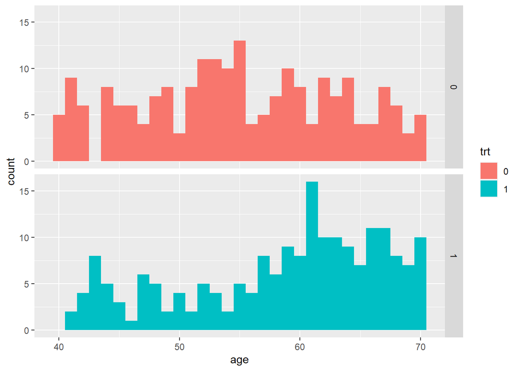

```r
mi$trt <- as.factor(mi$trt) #Change to factor (2 levels)
require(ggplot2)

## 1. Patients receiving the newer treatment tend to be older
ggplot(mi, aes(x=age, fill=trt)) + #set axis
geom_histogram(binwidth=1) + #draw histogram with bin width 1
facet_grid(trt ~ .) #https://ggplot2-book.org/facet.html#facet-grid
```

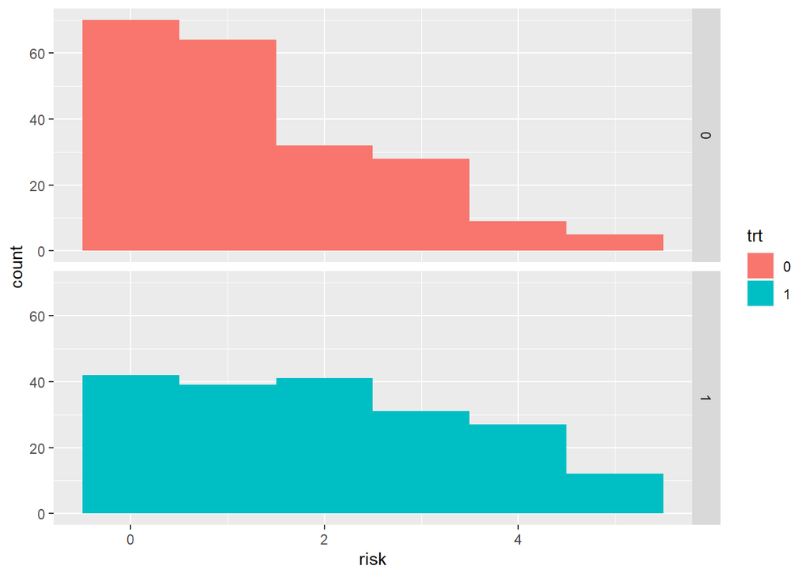

```r
## 2. Patients receiving the newer treatment tend to have higher risk
ggplot(mi, aes(x=risk, fill=trt)) + geom_histogram(binwidth=1) + facet_grid(trt~.)
```

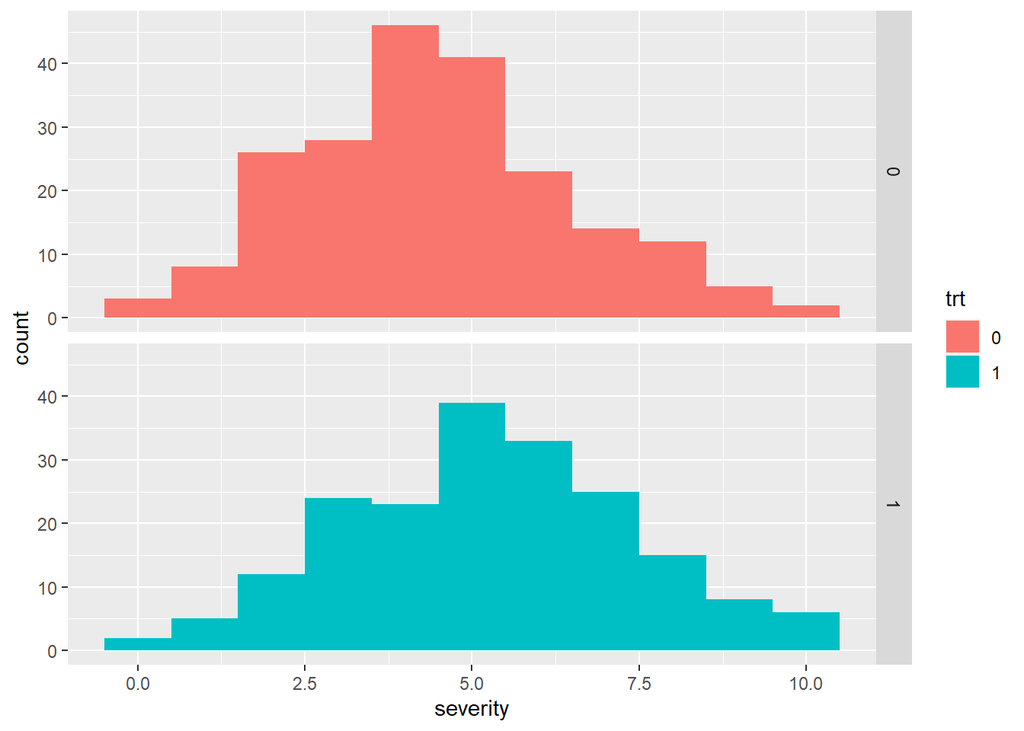

```r
## 3. Patients receiving the newer treatment are slightly more severe
ggplot(mi, aes(x=severity, fill=trt)) + geom_histogram(binwidth=1) + facet_grid(trt~.)
```

```r
#These factors are highly associated with mortality, need to take account into analysis

## Other graphs
# Continuous variable: ggplot(data, aes(x=statin, y=age)) + geom_boxplot(aes(fill=statin)) + coord_flip()
# Categorical variable: ggplot(data, aes(x=male, fill=factor(statin))) + geom_bar() + facet_grid(statin ~ .) + scale_x_continuous(breaks=seq(0, 1))
```

## 2.1 Rationale of PS

- Used for adjusting confounding
  - If observed **less than 10 events** per level of the predictors, it will be under-powered to use regression for adjusting confounding
  - PS has higher power and is more robust
1. A propensity score p<sub>i</sub> is derived for each case
   - p<sub>i</sub> = the probability/propensity of assigning to treatment for individual i  
     **the relationship between exposure and X**
   - Depends on the confounders/covariates/predictors X
     - May include interaction term to increase accuracy
   - Not depends on the outcome Y
2. Compare (treatment vs no treatment) individuals with similar propensity scores
   - Difference in the outcome due to the treatment effect only
   - Estimate the conditional effect: E(Y<sub>1</sub>-Y<sub>0</sub>|X) (the causal relationship given/adjusting confounder)

[figure not shown]

Assumptions

1. **Conditional independence / unconfoundedness**  
   Treatment assignment only depends on X, not depends on Y
2. **Common support / overlap condition**  
   P(T=1|X) < 1 for some observed predictors X
   - P(T=1|X) = 1 => all individuals with observed predictors X are treated and no ‘similar’ control can be found for comparison
   - *Need to have sample in both group for each propensity score*
   - Need to ensure **sufficient sample size** between treatment groups for comparison

## 2.2 Formula to derive PS

- logistic regression (predict treatment vs control) – logit(p<sub>i</sub>) = X<sub>i</sub>β
  - `ps.model <- glm(exposure ~ confounders X, data, family)`
  - `ps <- predict(ps.model, type='response')`
- multinomial regression (several treatment groups)
- other models can also be considered, e.g. classification trees, probit regression

  ```r
  ps.model <- glm(trt ~ age + risk + severity, data=mi, family=binomial)
  summary(ps.model) #ps.model to predict treatmnet assignment
  ```

  ```
  ##
  ## Call:
  ## glm(formula = trt ~ age + risk + severity, family = binomial,
  ##     data = mi)
  ##
  ## Deviance Residuals:
  ##     Min       1Q   Median       3Q      Max
  ## -1.6582  -1.0655  -0.7539   1.1115   1.7581
  ##
  ## Coefficients:
  ##             Estimate Std. Error z value Pr(>|z|)
  ## (Intercept) -2.73907    0.82803  -3.308  0.00094 ***
  ## age          0.03026    0.01517   1.995  0.04606 *
  ## risk         0.17966    0.08965   2.004  0.04509 *
  ## severity     0.13245    0.05157   2.568  0.01022 *
  ## ---
  ## Signif. codes:  0 '***' 0.001 '**' 0.01 '*' 0.05 '.' 0.1 ' ' 1
  ##
  ## (Dispersion parameter for binomial family taken to be 1)
  ##
  ##     Null deviance: 553.88  on 399  degrees of freedom
  ## Residual deviance: 521.04  on 396  degrees of freedom
  ## AIC: 529.04
  ##
  ## Number of Fisher Scoring iterations: 4
  ```

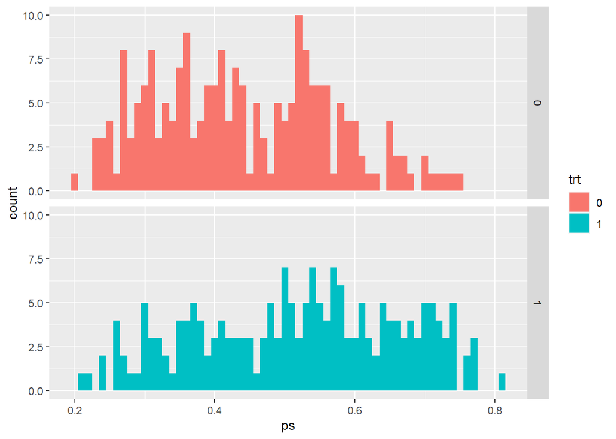

  ```r
  #common support in the range 0.2 – 0.8. Fulfill the assumption.
  ```

## 2.3 PS analysis

### A. Stratification

- Rationale: Treatment effect is estimated within each stratum –> Overall effect can be estimated by (weighted) mean of the stratum-specific treatment effect
- Stratification:
  - `ps.boundary <- quantile(ps, probs)` probs = probability with values
  - `cut(ps, ps.boundary,...)`

```r
##Stratification
ps.boundary <- quantile(mi$ps, 0:5/5) #separate into 6 quantile
ps.boundary
mi$psq <- cut(mi$ps, ps.boundary, right=F, include.lowest=T, label=1:5) # turn 6 quantile into 5 groups
head(mi)
```

```
##        0%       20%       40%       60%       80%      100%
## 0.2014026 0.3458898 0.4271172 0.5255349 0.6054821 0.8082802
##   age male risk severity trt death        ps psq
## 1  48    1    3        8   0     0 0.5773106   4
## 2  59    1    4        6   1     0 0.6362960   5
## 3  67    1    3        6   0     1 0.6506088   5
## 4  51    1    0        6   0     0 0.4009893   2
## 5  56    1    1        6   1     0 0.4824049   3
## 6  60    1    1        6   0     0 0.5126509   3
```

#### Check balance across treatment groups

##### M1 Graphs

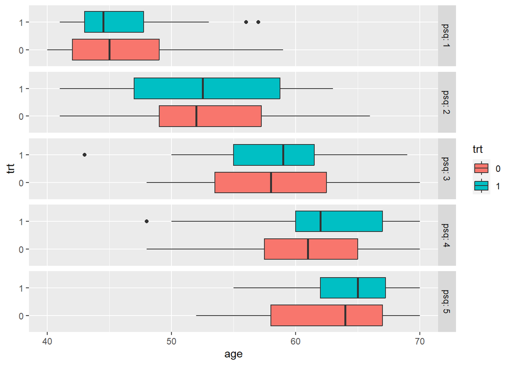

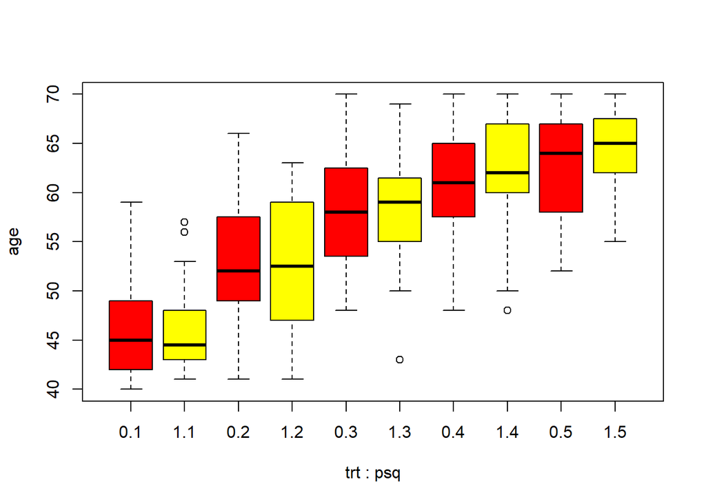

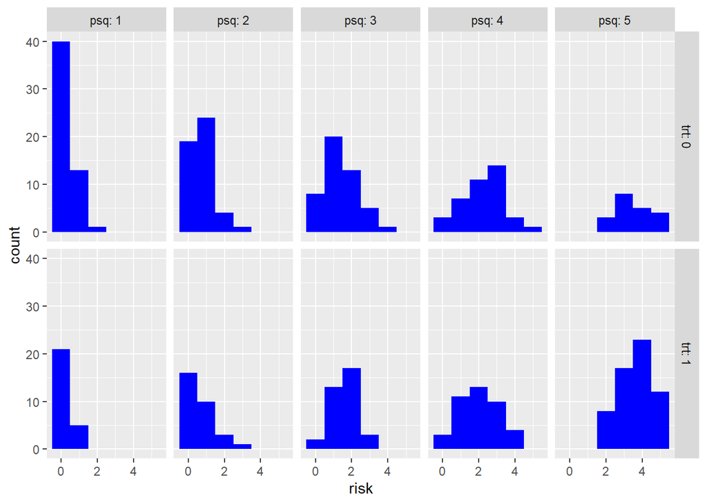

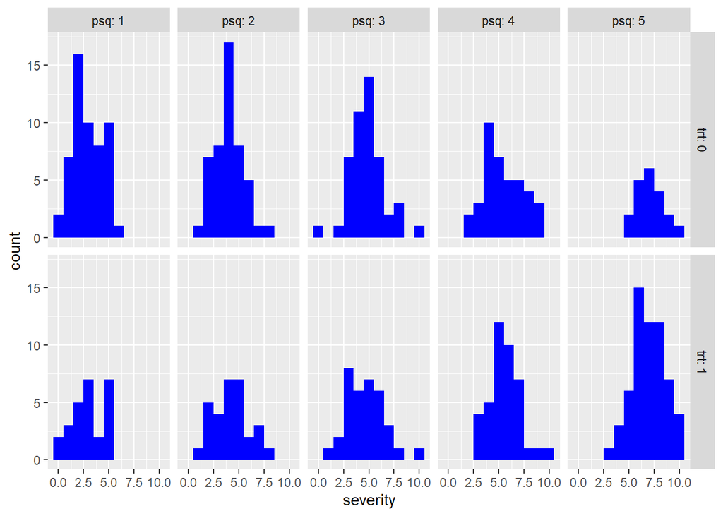

```r
##Check if it's balanced within each strata
## Age by PS strata (continuous variable)
ggplot(mi, aes(x=trt, y=age)) +
  geom_boxplot(aes(fill=trt)) +
  facet_grid(psq ~ .,labeller=label_both) + coord_flip()
with(mi, boxplot(age ~ trt*psq, col=c("red", "yellow")))

## Risk by PS strata (categorical variable)
ggplot(mi, aes(x=risk)) +
  geom_histogram(binwidth=1, fill='blue') +
  facet_grid(trt ~ psq, labeller=label_both)

## Severity by PS strata (categorical variable)
ggplot(mi, aes(x=severity)) +
  geom_histogram(binwidth=1,fill='blue') +
  facet_grid(trt ~ psq, labeller=label_both)
```

##### M2 T-statistics

- **Compare t-statistics (unadjusted vs adjusted for PS strata) by linear regression**
- Note: assume continuous outcome for risk and severity

```r
#For age
summary(lm(age~trt, data=mi)) #Unadjusted: 4.41
summary(lm(age~trt+psq, data=mi)) #Adjusted: 0.73

#For risk
summary(lm(risk~trt, data=mi)) #Unadjusted: 4.75
summary(lm(risk~trt+psq, data=mi)) #Adjusted: -0.16

#For severity
summary(lm(severity~trt, data=mi)) #Unadjusted: 3.84
summary(lm(severity~trt+psq, data=mi)) #Adjusted: 0.15
## Since t-statistics are much smaller, all three factors are much more balanced in the PS strata

## Simpler code (not taught in lecture); example dataset from 2023_Q1:
#For age
c(coef(summary(lm(age~statin, data=data)))[2,3], coef(summary(lm(age~statin+psq, data=data)))[2,3])
#For BMI
c(coef(summary(lm(bmi~statin, data=data)))[2,3], coef(summary(lm(bmi~statin+psq, data=data)))[2,3])
#For male
c(coef(summary(glm(male~statin, data=data, family=binomial)))[2,3], coef(summary(glm(male~statin+psq, data=data, family=binomial)))[2,3])
# For comorbidity
data$comorbid.s <- as.factor(data$comorbid.s)
c(coef(summary(glm(comorbid.s~statin, data=data, family=binomial)))[2,3], coef(summary(glm(comorbid.s~statin+psq, data=data, family=binomial)))[2,3])
```

[figure not shown]

##### M3 Mean standardized difference

May also assess balance by mean standardized difference

```r
## Not taught in lecture; method from google; example dataset from 2023_Q1:
library(tableone)
cols <- c("age", "bmi","male", "comorbid.s")
# Number of participants and SMD across treatment group before stratification
mytable <- CreateTableOne(vars=cols, factorVars = c("male", "comorbid.s"), strata=c("statin"), data=data)
x <- print(mytable, smd=T)
write.csv(x,"output.csv")
# Number of participants across treatment group after stratification
mytable2 <- CreateTableOne(vars=cols, factorVars = c("male", "comorbid.s"), strata=c("statin","psq"), data=data)
y <- print(mytable2)
write.csv(y,"output2.csv")
# SMD across treatment group after stratification
list1 <- c()
for (i in 1:5) {
  mytable <- CreateTableOne(vars=cols, factorVars = c("male", "comorbid.s"), strata=c("statin"), data=data[which(data$psq==i),])
  list1[[i]] <- round(ExtractSmd(mytable)[1:4,],2)
}
list1
```

#### Estimate after adjusting PS

```r
### MI mortality by PS strata

mean.tp <- aggregate(death~trt+psq, data=mi, FUN=mean) #1. mean of death grouped by treatment and PS strata
count.tp <- aggregate(death~trt+psq, data=mi, FUN=length) #2. no. of row grouped by treatment and PS strata
var.tp <- aggregate(death~trt+psq, data=mi, FUN=var) #3. variance of death grouped by treatment and PS strata
n.psq <- as.numeric(table(mi$psq)) #4. no. of row per PS strata (80,78,82,80,80)

##Overall treatment effect = sum of [(mean death in treatment - mean death in control) * no. of observations in each strata] / total no. of observations
cbind(mean.tp, count.tp$death)
sum((mean.tp$death[mean.tp$trt==1]-mean.tp$death[mean.tp$trt==0])*n.psq)/sum(n.psq) #-6%

##Variance of treatment effect = sum of [(variance of death in each strata/no. of observations in each strata) * no. of observations per strata^2 ] / total no. of observations^2
cbind(var.tp, count.tp$death)
sum((var.tp$death/count.tp$death)*rep(n.psq, each=2)^2)/sum(n.psq)^2 #0.00159

##95%CI
-0.0603 + 1.96*c(-1,1)*sqrt(0.00159) #95%CI (-0.14, 0.02)
```

```
##    trt psq      death count.tp$death
## 1    0   1 0.11111111             54
## 2    1   1 0.03846154             26
## 3    0   2 0.20833333             48
## 4    1   2 0.16666667             30
## 5    0   3 0.14893617             47
## 6    1   3 0.17142857             35
## 7    0   4 0.30769231             39
## 8    1   4 0.14634146             41
## 9    0   5 0.25000000             20
## 10   1   5 0.20000000             60
## [1] -0.06031414
##    trt psq      death count.tp$death
## 1    0   1 0.10062893             54
## 2    1   1 0.03846154             26
## 3    0   2 0.16843972             48
## 4    1   2 0.14367816             30
## 5    0   3 0.12950971             47
## 6    1   3 0.14621849             35
## 7    0   4 0.21862348             39
## 8    1   4 0.12804878             41
## 9    0   5 0.19736842             20
## 10   1   5 0.16271186             60
## [1] 0.001592993
## [1] -0.13845462  0.01785462
```

### B. Matching

1. Match each treated individual to 1 or n individuals from the control group
   - Methods
     1. Nearest-neighbor matching – those with similar PS are matched
     2. Caliper matching – match control to cases with PS within a preset a preset distance e.g. 0.2
     3. Mahalanobis metric matching – standardized squared distance relative to variation
     4. Stratification is indeed a kind of matching by range
2. Compare outcome in the ‘case’ vs ‘control’
   - With tests e.g. paired t-test for continuous outcome, McNemar’s test for categorical outcome
   - Unconditional or conditional analysis (on matched pairs/sets)
- `matchit(formula, data, method = “nearest”, distance = “logit”,…)` (in package: MatchIt)
  - **formula** syntax similar to glm
  - **data** data frame to be used
  - **method** specifies a matching method: “exact”, “nearest” (nearest neighbor matching), “optimal”, and “subclass“ (subclassification)
  - **distance** specifies the method used to estimate the distance measure. The default is logistic regression, “logit”
  - Then `match.data(matchit object)` to construct a matched dataset

```r
##Construct a matched dataset
require(MatchIt)
m.out <- matchit(trt ~ age + risk + severity, data = mi, method = "subclass", subclass=20)
#subclass > 5 is good matching
matched.mi <- match.data(m.out) #construct a matched dataset from "matchit" object
matched.mi[matched.mi$subclass==1,] #can check subclass 1. Note ps=distance. Data with subclass = 1 also has psq = 1

##Propensity score matching
clr.mi <- clogit(death ~ trt + strata(subclass), data=matched.mi)
summary(clr.mi)
#OR for clot-busting drug: 0.65 (95%CI: 0.37, 1.14)
```

```
##     age male risk severity trt death        ps psq  distance   weights subclass
## 27   43    1    0        1   1     0 0.2132211   1 0.2132211 1.0000000        1
## 31   42    1    0        2   0     0 0.2308658   1 0.2308658 0.5416667        1
## 35   48    1    1        1   0     0 0.2739481   1 0.2739481 0.5416667        1
## 45   45    1    0        3   0     0 0.2728490   1 0.2728490 0.5416667        1
## 52   46    1    0        1   0     0 0.2288440   1 0.2288440 0.5416667        1
## 55   48    1    0        2   1     0 0.2646589   1 0.2646589 1.0000000        1
## 64   40    1    0        4   0     0 0.2691281   1 0.2691281 0.5416667        1
## 76   47    1    0        2   1     0 0.2588127   1 0.2588127 1.0000000        1
## 79   40    1    0        4   0     0 0.2691281   1 0.2691281 0.5416667        1
## 81   49    1    0        1   0     0 0.2452549   1 0.2452549 0.5416667        1
## 112  46    1    0        2   0     0 0.2530512   1 0.2530512 0.5416667        1
## 127  42    1    0        3   0     1 0.2552161   1 0.2552161 0.5416667        1
## 132  41    1    0        3   0     0 0.2495077   1 0.2495077 0.5416667        1
## 134  44    1    0        2   0     0 0.2417852   1 0.2417852 0.5416667        1
## 156  40    1    0        3   0     0 0.2438852   1 0.2438852 0.5416667        1
## 173  44    1    0        3   0     0 0.2668875   1 0.2668875 0.5416667        1
## 214  44    1    0        2   1     0 0.2417852   1 0.2417852 1.0000000        1
## 217  56    1    0        0   1     0 0.2602374   1 0.2602374 1.0000000        1
## 232  40    1    0        3   0     0 0.2438852   1 0.2438852 0.5416667        1
## 240  45    1    0        0   0     1 0.2014026   1 0.2014026 0.5416667        1
## 250  53    1    0        1   0     0 0.2683406   1 0.2683406 0.5416667        1
## 265  46    1    0        2   0     0 0.2530512   1 0.2530512 0.5416667        1
## 266  51    1    1        0   0     1 0.2657371   1 0.2657371 0.5416667        1
## 267  45    1    0        3   1     0 0.2728490   1 0.2728490 1.0000000        1
## 285  43    1    0        2   1     0 0.2362820   1 0.2362820 1.0000000        1
## 294  42    1    0        2   0     0 0.2308658   1 0.2308658 0.5416667        1
## 322  48    1    0        0   1     0 0.2163978   1 0.2163978 1.0000000        1
## 333  47    1    1        1   1     0 0.2679715   1 0.2679715 1.0000000        1
## 357  43    1    0        3   1     0 0.2610096   1 0.2610096 1.0000000        1
## 363  54    1    0        1   0     0 0.2743224   1 0.2743224 0.5416667        1
## Call:
## coxph(formula = Surv(rep(1, 400L), death) ~ trt + strata(subclass),
##     data = matched.mi, method = "exact")
##
##   n= 400, number of events= 70
##
##         coef exp(coef) se(coef)      z Pr(>|z|)
## trt1 -0.4275    0.6521   0.2857 -1.496    0.135
##
##      exp(coef) exp(-coef) lower .95 upper .95
## trt1    0.6521      1.533    0.3725     1.142
##
## Concordance= 0.554  (se = 0.033 )
## Likelihood ratio test= 2.28  on 1 df,   p=0.1
## Wald test            = 2.24  on 1 df,   p=0.1
## Score (logrank) test = 2.26  on 1 df,   p=0.1
```

### C. Adjustment by fitting linear/logistic regression

- Propensity score as the only predictor to predict outcome

```r
lr.ps <- glm(death~trt+ps, data=mi, family=binomial)
exp(coef(lr.ps))
exp(confint(lr.ps))
#OR for clot-busting drug = 0.611, 95% CI = (0.35, 1.06)
```

```
## (Intercept)        trt1          ps
##  0.06612525  0.61067986 16.66896399
##                  2.5 %      97.5 %
## (Intercept) 0.02368166   0.1733016
## trt1        0.34705278   1.0591376
## ps          2.35437201 125.5768623
```

## Limitations of PS analysis

1. Assumption of unconfoundedness is not testable
2. Cannot control for unobserved confounders (reduce biases but cannot ensure whether significant biases remain)
3. Need larger samples to achieve balance of patient characteristics (similar to randomized design)
   - sufficient overlap of characteristics across treatment groups is needed for accurate estimation of treatment effect